# A unified framework for weighted parametric group sequential design (WPGSD) Introduction and Example

# 1 Background

The weighted parametric group sequential design (WPGSD) (Anderson et al. (2022)) approach allows one to take advantage of the known correlation structure in constructing efficacy bounds to control family-wise error rate (FWER) for a group sequential design. Here correlation may be due to common observations in nested populations, due to common observations in overlapping populations, or due to common observations in the control arm. This document illustrates the use of the WPGSD R pacakge to implement this approach.

# 2 Methods and Examples

## 2.1 Closed Testing and Parametric Tests

We aim to control the familywise error rate (FWER) at level $\alpha$. Let $J \subseteq I$. The intersection hypothesis $H_J$ assumes the null hypothesis for all individual hypotheses $H_i$ with $i \in J$. Closed testing principle is as follows: if for all sets $J \subseteq I$ with $j \in J$, $H_J$ can be rejected at level $\alpha$, then $H_j$ can be rejected. Weighted parametric tests can be used for this: Bretz et al. (2011), Xi et al. (2017) for fixed designs or Maurer and Bretz (2013) for group sequential.

## 2.2 Consonance

A closed procedure is called consonant if the rejection of the complete intersection null hypothesis $H_I$ further implies that at least one elementary hypothesis $H_i, i \in I$, is rejected. Consonance is a desirable property leading to short-cut procedures that give the same rejection decisions as the original closed procedure but with fewer operations. For WPGSD, consonance does not always hold and in general the closed-testing procedure is required.

## 2.3 Group Sequential Design Notations and Assumptions

- A set $I$ of hypotheses for $i \in I$.
- $K$ group sequential analyses, $k=1,⋯,K$
- Single endpoint
  - Not required, and can be generalized
- Assume tests $Z_{ik}$, $i \in I$, $1 \leq k \leq K$ where a large $Z_{ik}$ is used to reject $H_i$

## 2.4 Correlation Structure

- Notation
  - Events for individual hypothesis $H_i$,$i \in I$ at analysis k denoted by $n_{ik}$.
  - Assume the same endpoint for all hypotheses (can be relaxed)
  - For binary or continuous outcomes $n_{ik}$ represents sample size
  - $Z_{ik}$ is standardized normal test for treatment effect for individual hypothesis $H_i$ at analysis $k$
  - Denote $n_{i\wedge i^\prime,k\wedge k^\prime}$ as the number of observations (or events) included in both $Z_{ik}$ and $Z_{i^\prime k^\prime}$, $i\in I$, $1\le k\le K$.
- Key result
  $$\hbox{Corr}(Z_{ik},
  Z_{i^\prime k^\prime }) = \frac{n_{i\wedge i^\prime ,k\wedge k^\prime
  }}{\sqrt{n_{ik}n_{i^\prime k^\prime }}}$$
- Proof builds on standard group sequential theory (Chen et al. (2021))

## 2.5 Example 1: Overlapping Populations, Two Analyses

Following illustrates the first example, which has overlapping populations (e.g. due to biomarker) and is also example 1 in Anderson et al. (2022).

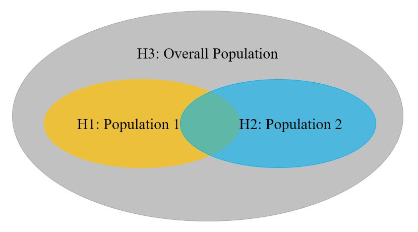

Ex1: Populations

The multiplicity strategy is defined as follows.

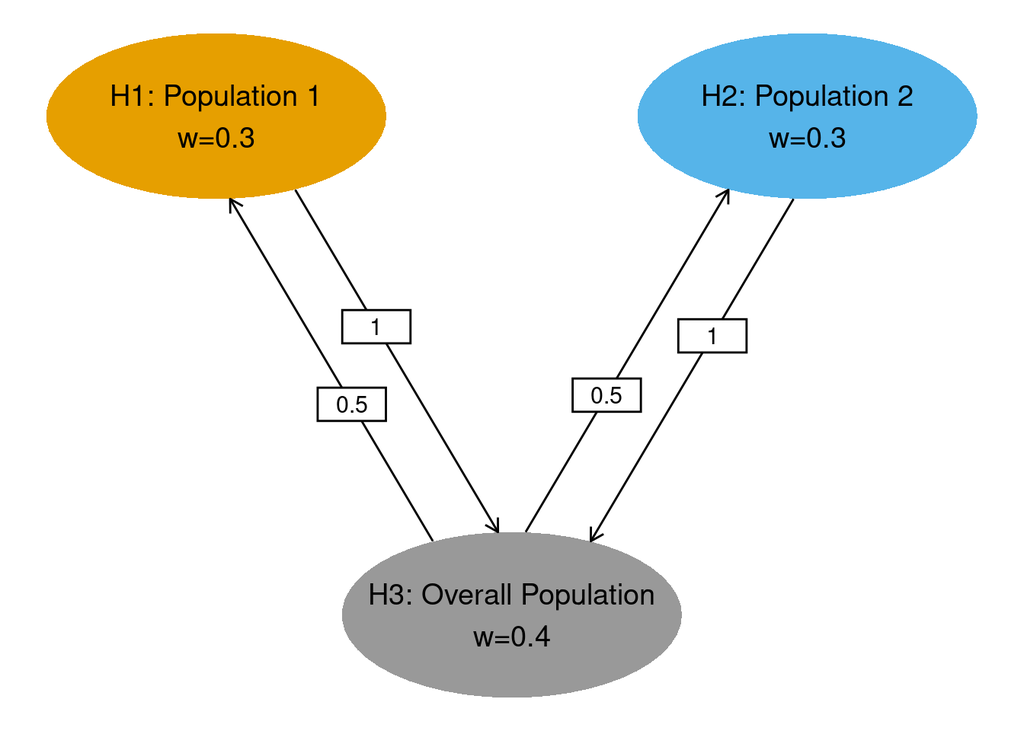

```r
> # transition matrix
> m <- matrix(c(0, 0, 1,
+               0, 0, 1,
+               0.5, 0.5, 0), nrow = 3, byrow = TRUE)
> # weight matrix
> w <- c(0.3, 0.3, 0.4)
>
> # multiplicity graph
> cbPalette <- c("#999999", "#E69F00", "#56B4E9")
>
> nameHypotheses <- c("H1: Population 1",
+                     "H2: Population 2",
+                     "H3: Overall Population")
>
> hplot <- hGraph(3,
+                 alphaHypotheses = w,
+                 m = m,
+                 nameHypotheses = nameHypotheses,
+                 trhw = .2, trhh = .1,
+                 digits = 5, trdigits = 3, size = 5, halfWid = 1,
+                 halfHgt = 0.5, offset = 0.2 , trprop = 0.4,
+                 fill = as.factor(c(2, 3, 1)),
+                 palette = cbPalette,
+                 wchar = "w")
> hplot
```

The event count of each hypothesis at each analysis is shown below.

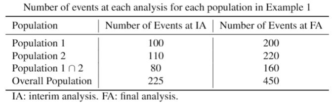

Ex1: Event count

The correlation matrix among test statistics is as follows.

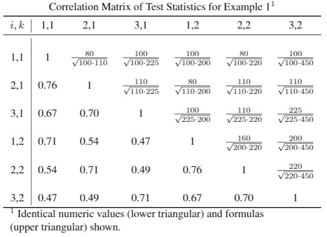

Ex1: Correlation

## 2.6 Example 2: Common Control, Two Analyses

Following illustrates the second example in which correlation comes from common control arm. This is also example 2 in Anderson et al. (2022).

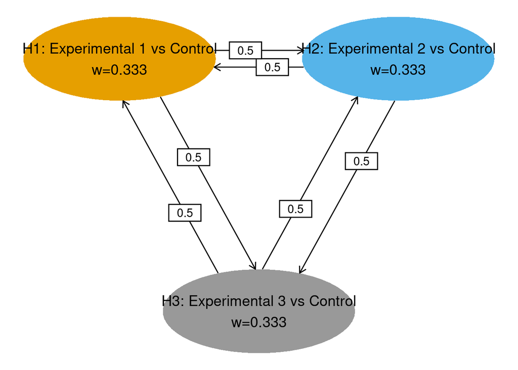

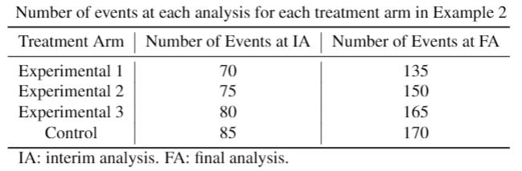

Ex2: Event count

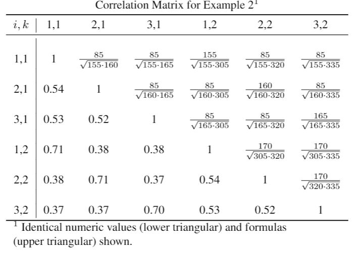

Ex2: Correlation

## 2.7 Hypotheses Set

These 2 examples each has 7 intersection hypotheses and the corresponding weighting strategies are illustrated below.

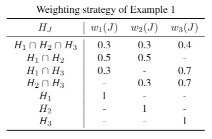

Ex1: Weighting Strategy

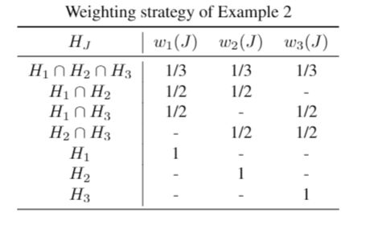

Ex2: Weighting Strategy

## 2.8 $\alpha$ Spending: 3 approaches

The WPGSD approach uses all known correlations between tests in the study. This relaxes bounds and allows increased power or smaller sample size. Three spending approaches have been proposed:

- Fixed spending (Fleming-Harrington-O’Brien (FHO) approach). Specify $0 < \alpha_1(J) < \alpha_2(J) < \ldots < \alpha_K(J) = \alpha(J) \leq \alpha$ for all $J\subseteq I$, where $\alpha(J)$ is the total alpha for intersection hypothesis $H_J$ according to the graphical approach.
- $\alpha$-spending approach 1. We choose a spending function family $f(t,\alpha)$ and set $\alpha_k(J)=f(t_k(J),\alpha(J))$ for $1\le k\le K$ for all intersection hypotheses $J\subseteq I$.
- $\alpha$-spending approach 2. For each elementary hypothesis $i$ ($i$ = 1, 2, , $m$), specify the $\alpha$-spending function family $f_i(t,\gamma)$ where $\gamma$ is the $\alpha$ level for the hypothesis and $f_i(t_{ik},\gamma)$ determines how much $\alpha$ to spend up to analysis $k$ for hypothesis $i$ when level $\gamma$ is allocated to the hypothesis. Then $\alpha_k(J) = \sum_{i \in J} f_i(t_{ik}, w_i(J)\alpha)$.

## 2.9 Bounds Computation: Parametric Test, Fixed Design (eg. Two Populations, One Analysis)

- Assume ($Z_1,Z_2$) bivariate normal with known correlation
- Find $\alpha$-inflation factor $c_J$ such that
  $$\alpha = P[\cup_{i \in J} \{p_i \leq
  c_Jw_{J,i}\alpha \}] = P[\cup_{i \in J} \{Z_i \geq
  \Phi^{-1}(1−c_Jw_{J,i}\alpha \}]$$
- Basic algorithm code in Bretz et al. (2011)

### 2.9.1 Bounds Computation: WPGSD - Fixed spending and $\alpha$ spending approach 1

- Assume for $j < k$ that bounds $c_{ij} (J), i \in J, j < k$, have already been set and remain unchanged.
- At analysis $k$, compute the correlation matrix of $Z_{ij}$, $i \in J$, $j = 1, \ldots, k$.

  i Initialize $\alpha_{k}^{*}(J) = \alpha_{k}(J) - \alpha_{k-1}(J)$.

  ii Set $b_{ik} = \Phi^{-1}(1 - w_{i}(J)\alpha_{k}^{*} (J))$, $i\in J$.

  iii Compute type I error rate up to analysis $k$
  $$1 -
  Pr(\cap_{i \in J} \{ Z_{ik} < b_{ik} \} \cap_{i \in J, j < k} \{
  Z_{ij} < c_{ij}(J) \} ).$$

  iv Update $\alpha_{k}^{*}(J)$ using root-finding with steps ii - iii until the type I error rate through analysis $k$ is controlled at $\alpha_{k}(J)$ for $H_J$. That is,
  $$1 - Pr(\cap_{i \in J} \{ Z_{ik} < b_{ik} \}
  \cap_{i \in J, j < k} \{ Z_{ij} < c_{ij}(J) \} ) = \alpha_{k}.$$

  v Set $c_{ik}(J) = b_{ik}$ from the previous step. The corresponding nominal $p$-value boundary is $p_{ik}(J)= 1-\Phi(c_{ik}(J)) = w_i(J)\alpha_k^*(J)$.
- Note: interim bound does not depend on future analyses. Solution only requires root finding for a single $\alpha_{k}^{*}(J)$ at a time, $k=1,…,K$. Requires multivariate normal computation from mvtnorm R package Genz et al. (2020).

### 2.9.2 Bounds Computation: WPGSD - $\alpha$ spending approach 2

- Assume for $j < k$ that bounds $c_{ij} (J), i \in J, j < k$, have already been set and remain unchanged.
- At analysis $k$, compute the correlation matrix of $Z_{ij}$, $i \in J$, $j = 1, \ldots, k$.

  i Determine what the nominal $p$-value boundary would be for each elementary hypothesis in $J$ for a weighted Bonferroni test in a group sequential design as described in Maurer and Bretz (2013). Let these nominal $p$-value boundaries be $\alpha^\prime_{ik}(J)$.

  ii Choose an inflation factor $\xi_{k}(J) > 1$ and set
  $$b_{ik} =
  \Phi^{-1}(1 - \xi_k(J) \alpha^\prime_{ik}(J)).$$

  iii Update $\xi_k(J)$ until this type I error rate up to analysis $k$ is controlled at $\alpha_{k}(J)$ for $H_J$. That is,
  $$1 - Pr(\cap_{i \in J} \{ Z_{ik} < b_{ik} \}
  \cap_{i \in J, j < k} \{ Z_{ij} < c_{ij}(J) \} ) =
  \alpha_{k}(J).$$

  iv After the appropriate $\xi_k(J)$ has been derived, the nominal $p$-value boundaries are $p_{ik}(J)=\xi_k(J) \alpha^\prime_{ik}(J)$, and $b_{ik}$ is computed as in step ii, we set $c_{ik}(J) = b_{ik}$.
- Note: interim bound does not depend on future analyses. Solution only requires root finding for a single $\xi_k(J)$ at a time, k=1,…,K. Requires multivariate normal computation from mvtnorm R package Genz et al. (2020).